# Binning Core Shell Data

The paper [“A classification EM algorithm for binned data”](http://www.sciencedirect.com/science/article/pii/S0167947305002082) made me think it may be a good idea to try binning the pixel intensities for the core shell videos in order to differentiate between the background, core and shell. This is my attempt to implement their method.

Below is an example frame from the core shell video we have both full and downsampled to 5%.

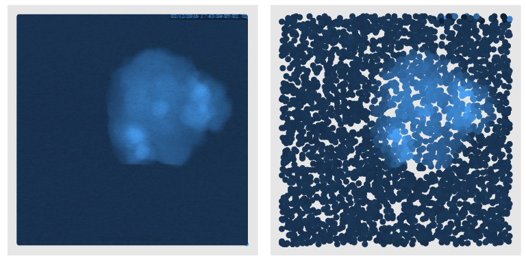

```r
#framei <- filter(framei,Y<250,Y>5)
framei_samp <- sample_frac(framei,size = .05)
full <- qplot(X,Y,colour=Intensity,data=framei)+theme_em()
sampled <- qplot(X,Y,colour=Intensity,data=framei_samp,size=I(2.5))+theme_em()
grid.arrange(full,sampled,nrow=1)
```

The goal is to identify the cores and shells so we can derive sizes of each of functions of that. There doesn’t appear to be the gradient effect that’s present in the anode videos so we could use the standard GMM method to cluster each of the samples pixels, but it’s really difficult to identify/differentiate core and shell with this method (I think).

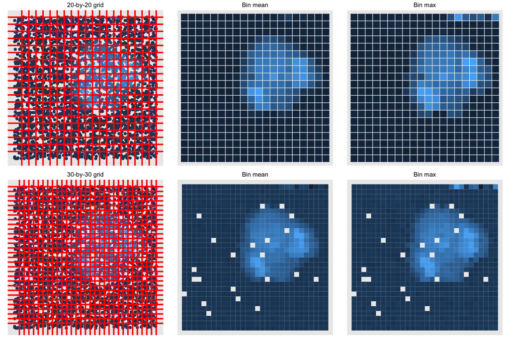

```r
gridx <- seq(min(framei_samp$X),max(framei_samp$X),length=21)
gridx <- gridx[-1]
centers <- min(gridx)/2+gridx
#Bin the downsampled image
framei_samp$Xcat <- classify_onedim(framei_samp$X,gridx)
framei_samp$Ycat <- classify_onedim(framei_samp$Y,gridx)
framei_samp <- mutate(framei_samp,XCen=centers[framei_samp$Xcat],YCen=centers[framei_samp$Ycat])
framei_samp$Cat <- framei_samp$Xcat+(framei_samp$Ycat-1)*max(framei_samp$Xcat)
Int_Sum_ind_20 <- framei_samp%>%group_by(Cat)%>%summarize(X=mean(XCen), Y=mean(YCen), Mean_intensity=mean(Intensity), IntSD=sd(Intensity), Max_int=max(Intensity))
lines_20 <- sampled+geom_hline(yintercept=gridx,col=2,size=1.5)+geom_vline(xintercept = gridx,col=2,size=1.5)+ggtitle("20-by-20 grid")
binned_mean_20 <- qplot(X,Y,data=Int_Sum_ind_20,colour=Mean_intensity,size=I(6.5),geom='point',shape=I(15))+theme_em()+ggtitle("Bin mean")
binned_max_20 <- qplot(X,Y,data=Int_Sum_ind_20,colour=Max_int,size=I(6.5),geom='point',shape=I(15))+theme_em()+ggtitle("Bin max")
#grid.arrange(lines,binned_max,binned_max,nrow=1)
gridx <- seq(min(framei_samp$X),max(framei_samp$X),length=31)
gridx <- gridx[-1]
centers <- min(gridx)/2+gridx
#Bin the downsampled image
framei_samp$Xcat <- classify_onedim(framei_samp$X,gridx)
framei_samp$Ycat <- classify_onedim(framei_samp$Y,gridx)
framei_samp <- mutate(framei_samp,XCen=centers[framei_samp$Xcat],YCen=centers[framei_samp$Ycat])
framei_samp$Cat <- framei_samp$Xcat+(framei_samp$Ycat-1)*max(framei_samp$Xcat)
Int_Sum_ind_30 <- framei_samp%>%group_by(Cat)%>%summarize(X=mean(XCen), Y=mean(YCen), Mean_intensity=mean(Intensity), IntSD=sd(Intensity), Max_int=max(Intensity))
lines_30 <- sampled+geom_hline(yintercept=gridx,col=2,size=1.5)+geom_vline(xintercept = gridx,col=2,size=1.5)+ggtitle("30-by-30 grid")
binned_mean_30 <- qplot(X,Y,data=Int_Sum_ind_30,colour=Mean_intensity,size=I(4.5),geom='point',shape=I(15))+theme_em()+ggtitle("Bin mean")
binned_max_30 <- qplot(X,Y,data=Int_Sum_ind_30,colour=Max_int,size=I(4.5),geom='point',shape=I(15))+theme_em()+ggtitle("Bin max")
grid.arrange(lines_20,binned_mean_20,binned_max_20,lines_30,binned_mean_30,binned_max_30,nrow=2)
```

Now we need to classify each pixel (original method), or classify the bins. Binning is great computationally because it reduces the number of data points from 3277 to $b^2=$ 900 where $b$ is the chosen number of bins.

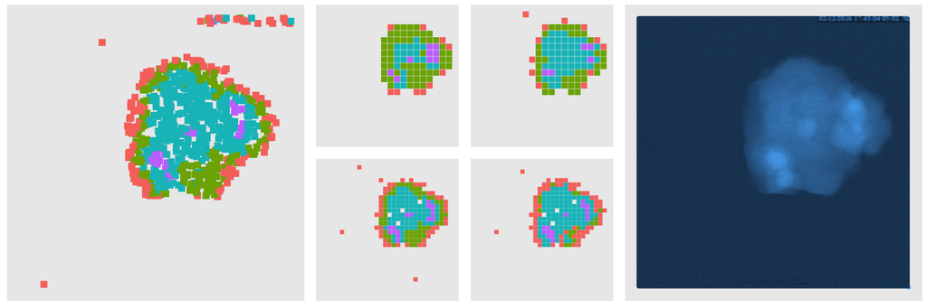

```r
#apply EM to individual pixel intensity
pixel_res <- EM_alg_mu_cpp(z=framei_samp$Intensity,p = rep(1/5,5), mu = c(50,100,120,150,200), sigma = rep(4,5),eps = 1e-5,maxit = 1000)
framei_samp$estimated_class <- apply(pixel_res$wmat,1,which.max)
pixel_res <- qplot(X,Y,data=filter(framei_samp,estimated_class>1),colour=as.factor(estimated_class),size=I(3.5),geom='point',shape=I(15))+
  xlim(c(0,255))+ylim(c(0,255))+theme_em()
#apply EM to mean 20-by-20 bin intensity
mean_res <- EM_alg_mu_cpp(z=Int_Sum_ind_20$Mean_intensity,p = rep(1/5,5), mu = c(50,100,120,150,200), sigma = rep(4,5),eps = 1e-5,maxit = 1000)
Int_Sum_ind_20$Mean_class <- apply(mean_res$wmat,1,which.max)
mean_res_20 <- qplot(X,Y,data=filter(Int_Sum_ind_20,Mean_class>1),colour=as.factor(Mean_class),size=I(3),geom='point',shape=I(15))+
  xlim(c(0,255))+ylim(c(0,255))+theme_em()
#apply EM to max 20-by-20 bin intensity
max_res <- EM_alg_mu_cpp(z=Int_Sum_ind_20$Max_int,p = rep(1/5,5), mu = c(50,100,120,150,200), sigma = rep(4,5),eps = 1e-5,maxit = 1000)
Int_Sum_ind_20$Max_class <- apply(max_res$wmat,1,which.max)
max_res_20 <- qplot(X,Y,data=filter(Int_Sum_ind_20,Max_class>1),colour=as.factor(Max_class),size=I(3),geom='point',shape=I(15))+
  xlim(c(0,255))+ylim(c(0,255))+theme_em()
#apply EM to mean 30-by-30 bin intensity
mean_res <- EM_alg_mu_cpp(z=Int_Sum_ind_30$Mean_intensity,p = rep(1/5,5), mu = c(50,100,120,150,200), sigma = rep(4,5),eps = 1e-5,maxit = 1000)
Int_Sum_ind_30$Mean_class <- apply(mean_res$wmat,1,which.max)
mean_res_30 <- qplot(X,Y,data=filter(Int_Sum_ind_30,Mean_class>1),colour=as.factor(Mean_class),size=I(2),geom='point',shape=I(15))+
  xlim(c(0,255))+ylim(c(0,255))+theme_em()
#apply EM to max 30-by-30 bin intensity
max_res <- EM_alg_mu_cpp(z=Int_Sum_ind_30$Max_int,p = rep(1/5,5), mu = c(50,100,120,150,200), sigma = rep(4,5),eps = 1e-5,maxit = 1000)
Int_Sum_ind_30$Max_class <- apply(max_res$wmat,1,which.max)
max_res_30 <- qplot(X,Y,data=filter(Int_Sum_ind_30,Max_class>1),colour=as.factor(Max_class),size=I(2),geom='point',shape=I(15))+
  xlim(c(0,255))+ylim(c(0,255))+theme_em()
lay <- rbind(c(1,1,2,3,6,6),
             c(1,1,4,5,6,6))
grid.arrange(grobs=list(pixel_res,mean_res_20,max_res_20,mean_res_30,max_res_30,full),layout_matrix=lay)
```